# Pertemuan 4 Praktikum MPDW

Muhammad Fadhil Hakim

2025-09-20

# 1. Bangkitkan model MA(2) dengan θ1=0.4 dan θ2=0.6 sebanyak 300 data (Manual dan dengan arima.sim)

## Pembangkitan data MA(2) secara manual

```r
set.seed(125)  # biar hasil sama setiap run

n <- 300
theta1 <- 0.4
theta2 <- 0.6

# --- Cara manual ---
# epsilon ~ N(0,1)
eps <- rnorm(n + 2)
y_manual <- numeric(n)

for (t in 3:(n+2)) {
  y_manual[t] <- eps[t] + theta1*eps[t-1] + theta2*eps[t-2]
}
y_manual <- y_manual[3:(n+2)]  # ambil data 300
y_manual <- ts(y_manual)
y_manual
```

```
## Time Series:
## Start = 1
## End = 300
## Frequency = 1
##   [1]  2.16442326  0.49380247  1.51760092 -1.98555473 -1.00035310 -1.31747446
##   [7] -0.36277692  0.44984541 -0.26558107  0.61721740  0.19460641  1.08038366
##  [13] -0.55650367  0.71556066  1.34760869  2.30729272 -0.07118958  1.30304787
##  [19]  0.10613035  2.07789994 -0.44226152  0.87211303 -0.99394859  0.56356739
##  [25] -2.00884603  0.04315398  0.01174840  1.08904591  0.76945965  2.66811067
##  [31]  0.11175559  1.84808631  1.32895695  2.21560217  1.13709974 -0.52803418
##  [37]  0.59142033 -1.91782748  0.17872539 -1.64227223  0.80048152 -1.44297643
##  [43]  0.74182760 -0.95719679 -0.52896531 -1.03993685  0.84464667 -0.34218164
##  [49]  1.37747945  0.83666276  1.17572908  1.77040083  1.38068927 -2.67362636
##  [55] -0.12927250 -3.13035027 -0.01338346 -1.53103162 -0.12061731 -1.53737008
##  [61] -0.78941427 -1.60509971 -0.19001746 -1.37001252 -0.44753813  0.68763600
```

[output cut: 39 more lines]

## Pembangkitan data MA(2) dengan arima.sim

```r
# --- Cara dengan arima.sim ---
y_arima <- arima.sim(model = list(ma = c(theta1, theta2)), n = n)
y_arima <- ts(y_arima)
y_arima
```

```
## Time Series:
## Start = 1
## End = 300
## Frequency = 1
##   [1] -0.060290308 -1.569581005 -1.270727558 -0.814548163 -0.226097912
##   [6]  0.179753359  0.632120035 -0.721645022 -0.855004591 -1.702908840
##  [11]  0.185413742  0.192514907 -1.266086662  0.335553000 -1.504666920
##  [16]  0.134172742 -0.230645478  0.745270240  1.179485275  1.829858369
##  [21]  0.958222340  0.819381868 -1.139679029 -0.939704236 -1.957953773
##  [26] -0.394558005  0.098505004  0.094817352 -0.750932165 -1.062027850
##  [31] -2.380163263 -1.151501290 -1.730897029  0.783955813 -0.985109352
##  [36]  2.076478516  2.593484272  2.415024640  0.594143417  0.200957872
##  [41]  0.336536163 -1.140056436 -2.133144398 -1.878147093 -2.451760297
##  [46] -0.792891724 -0.535498159 -2.422953148 -0.043216755 -1.655021987
##  [51]  1.407126887  0.186595898  0.394518598 -1.074768107 -1.042448157
```

[output cut: 49 more lines]

## Karakteristik data MA(2)

### Plot Time Series, ACF, PACF, dan EACF

```r
library(TSA)   # untuk EACF
```

```
## AR/MA
##   0 1 2 3 4 5 6 7 8 9 10 11 12 13
## 0 x x o o o o o o o o o  o  o  o
## 1 x x o o o o o o o o o  o  o  o
## 2 x x x o o o o o o o o  o  o  o
## 3 x x x o o o o o o o o  o  o  o
## 4 x x x x o o o o o o o  o  o  o
## 5 x x o x o o x o o o o  o  o  o
## 6 x x o x o o o o o o o  o  o  o
## 7 x x x o x o o o o o o  o  o  o
```

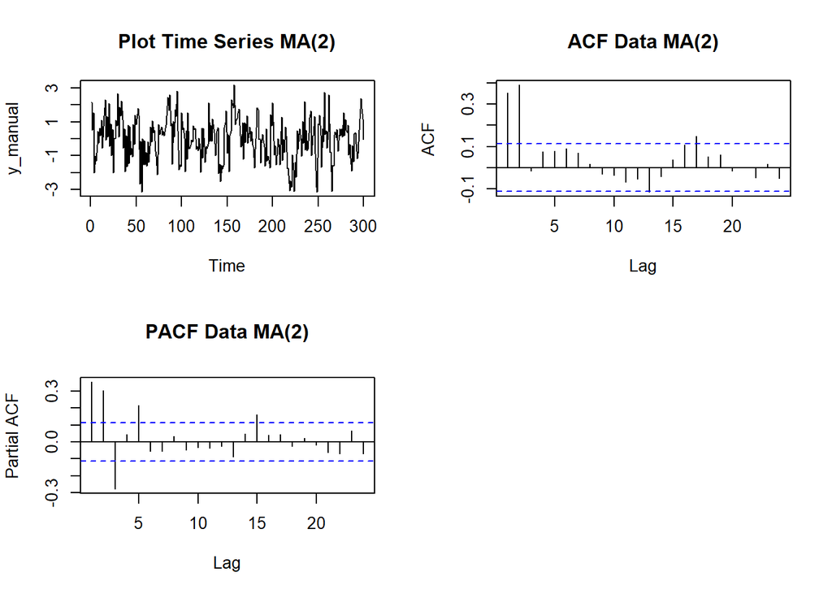

```r
par(mfrow=c(2,2))
plot.ts(y_manual, main="Plot Time Series MA(2)")
acf(y_manual, main="ACF Data MA(2)")
pacf(y_manual, main="PACF Data MA(2)")
eacf(y_manual)
```

rangkuman : 1). Data MA(2) yang dibangkitkan stasioner dalam rataan berdasarkan plot time series, 2). ACF menunjukkan pola cut off pada lag 2, 3). PACF menunjukkan pola tails off dan membentuk pola sinus, 4). EACF menunjukkan pola segitiga pada baris ke-2.

## Scatter Plot antar Lag

### Scatterplot Yt dengan Yt−1,Yt−2,Yt−3

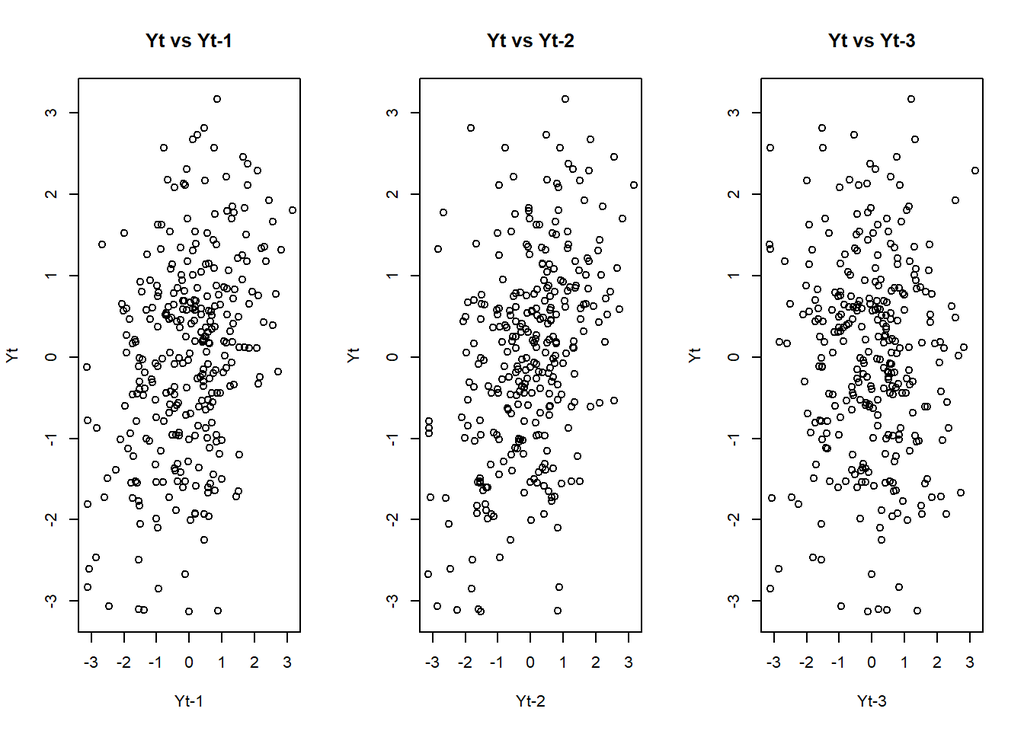

```r
par(mfrow=c(1,3))
plot(y_manual[-1], y_manual[-n], main="Yt vs Yt-1",
     xlab="Yt-1", ylab="Yt")
plot(y_manual[-c(1:2)], y_manual[-c((n-1):n)], main="Yt vs Yt-2",
     xlab="Yt-2", ylab="Yt")
plot(y_manual[-c(1:3)], y_manual[-c((n-2):n)], main="Yt vs Yt-3",
     xlab="Yt-3", ylab="Yt")
```

## Autokorelasi dari data bangkitan maupun teoritis

### Autokorelasi Data MA(2) Hasil Bangkitan

```r
acf_empiris_manual <- acf(y_manual, plot=FALSE)$acf[1:3]
acf_empiris_manual
```

```
## [1]  0.35389359  0.39158198 -0.01667181
```

```r
acf_empiris_arima <- acf(y_arima, plot=FALSE)$acf[1:3]
acf_empiris_arima
```

```
## [1] 0.51324459 0.41136526 0.02125612
```

### Autokorelasi Teoritis MA(2)

```r
# Varians proses
gamma0 <- 1 + theta1^2 + theta2^2
gamma1 <- theta1 + theta1*theta2
gamma2 <- theta2

rho1 <- gamma1/gamma0
rho2 <- gamma2/gamma0
rho3 <- 0

rho_teoritis <- c(rho1, rho2, rho3)
rho_teoritis
```

```
## [1] 0.4210526 0.3947368 0.0000000
```

### Perbandingan Autokorelasi Empiris dan Teoritis

```r
data.frame(Lag=1:3, ACF_Empiris_manual=acf_empiris_manual,  ACF_Empiris_arima=acf_empiris_arima ,ACF_Teoritis=rho_teoritis)
```

```
##   Lag ACF_Empiris_manual ACF_Empiris_arima ACF_Teoritis
## 1   1         0.35389359        0.51324459    0.4210526
## 2   2         0.39158198        0.41136526    0.3947368
## 3   3        -0.01667181        0.02125612    0.0000000
```

Dari hasil di atas, dapat dilihat bahwa autokorelasi empiris mendekati autokorelasi teoritis untuk lag 1, 2, dan 3, yang menunjukkan bahwa model MA(2) yang dibangkitkan sesuai dengan karakteristik teoritisnya.